# A First R Tutorial

Simon Hans Edasi

4/13/2023

### Q SCI 381 Introduction to Probability and Statistics: A First R tutorial

In these tutorials we are going to learn to use a powerful, and currently, the most commonly used software package, R. This package will significantly decrease the tedious calculations that once were a common part of statistical analysis. After learning how to use R, you will be able to use it in your other courses and mention the ability to use it on your resume!

NOTE: We are not going to work directly in R. We will be using an interface, R Markdown. An R Markdown file has an *.Rmd extension wile an R file has an* .R extension in its title. R Markdown allows us to type and run R script while also making printing and sharing all of the output of your work with others easier than in R. Using R Markdown permits printing all of the output of the scripts INCLUDING any plots that are created. In R, this requires much more work. Later in this tutorial, we will learn how to include plots in R.  
You will see why R Markdown is the preferred way of working with what you do in R if you wish to print out the results.

In these tutorials and the assignments, you will read a reference to the symbol “#” representing a comment or nonexecutable statement in R. Our R Markdown files have been written so that the “#” is not necessary for adding comment statements. What you are now reading is a comment statement in R Markdown. You do not need to precede these lines with a “#”. You may add lines like these as you like.

In R, comments are liberally used to explain your code and make it readable. You would be amazed by what you can forget in a short period of time after you have written some code. Don’t assume that you will remember anything about the code when you look at it later.

In these tutorials the following will give you an area to place your code (R script). Type your script between the `{r} and the closing`as shown below. If you need more space for writing code,that is easily done by using the “Enter” on your keyboard.

```r
# Enter your code (R script) in this space.  Note that I included a "#".
# See below for the meaning of this symbol.
```

If you want to add a comment statement in an area where you write code in R Markdown, then be sure to precede the statement with a “#” symbol. This is shown in the lines below.

```r
# This is a comment statement. I also used it in the code "chunk" above.
# Notice the three icons to the upper right of this block.  Hover your cursor over
#each one to see what they allow you to do.
```

An important comment before we begin these tutorials: Save your work often!

It is at the very least frustrating to work for a long time to figure out how to write some instructions only to mistakenly hit the wrong key or have the software package “bomb” or stop working (and that can and does happen!) and then have to redo everything. Let’s begin.

Please keep something in mind as you embark learning R (or any software), especially if you have never written a computer command before in as software package: be patient. Take it slow, but keep at it!

We will be here to help you when you need it, but please try to work things out on your own first.  
If you do that you will gain confidence and skill. You can always refer back to these tutorials and BC&P throughout the course.

As our guide to learning the basics of R, we are going to use:

```
A.  P. Beckerman, D. Z. Childs, and O. L. Petchey.
 2017 (2nd Edition). Getting Started with R:
 An Introduction for Biologists. Oxford.
```

We will refer to this text as BC&P.

I hope that you will find it supportive for a new learner and “user friendly”. The authors are British, so the word “maths” is not a misprint of “math”. The same is true of “colour”.

We will not use all of the text.

Many people have successfully learned to use R before you and you can do it also!

Our TAs and I are here to support you. We have your back. Try things on your own first, but when you just don’t get it, please ask us for help. We will not use all of the text.

Before doing this tutorial, please read pages iv - 8 (up to section 1.5) and pages 219 - 221 in BC&P and you will be asked to reread them after you have completed A Third R Tutorial.

Pages 219 - 221 are closing remarks, but it may help you to read them now before you start this tutorial. Reading these pages and completing these three tutorials will help you get started. The third tutorial will focus on creating useful plots (graphs) of data.  
This will be central to our study of statistics.

Feel free to read everything you like in BC&P beyond what is covered in these tutorials, especially if you think or know that you will be using R in your work or other courses. R is used in Q SCI 482 and 483 as well as many courses in BIOL, SAFS, SEFS, and SMEA. In this course, we will only use a samll amount of what R can really do.

As you read BC&P do it actively, i.e., with RStudio open on your computer. Use that computer to enter and RUN the scripts (code) in this tutorial and in BC&P. That active engagement will not only make learning the basics of R easier BUT more interesting!

This tutorial will introduce a few other functions  
that are resident in R for your use in doing operations more easily, but not mentioned in BC&P so that you will have a few more tools available in you R tool box.

As you work along with the text in BC&P, learn the good habits of writing and documenting your script. The text makes a great effort to point these out. Learning to do this now will permanently pay big dividends to you.

Welcome to RStudio. The flexible user interface for R. It consists of four panes with multiple tabs containing various options. We will learn to use these panes and many of the options.

R is the most widely used statisitcal software today. It is open source and free to download. But, here is a lesson in basic economics. It is free to download, but it is not really free.

You have to take your time to download it, set it up, learn its syntax and commands, and how to use it productively. That all takes time, and time is the most important and expensive asset we have. It can never be replaced or renewed. Economists call these costs opportunity costs. By this they mean that the cost of anything is your next most favored (preferred) alternative that you gave up to get what you selected. In this case, that is the time you could have spent doing something else. But, learning some R will help you later, so it will be worth your time. This ends our economics lesson. :-)

Many expert users have created functions that allow us to do data manipulation, statisitcal analyses, and plot our data and results in publication quality. If you wish, you can also learn to write your own fucntions to carry out your own analyses. Our use of R will be limited in Q SCI 381. We will not fully explore its capabilities, but now that you have it you can if you wish. We will be happy to help you. Since R is so widely used, the more you learn to do with it, the more career opportunities may be opened to you.

Before we start, go to the toolbar above, click on the “Help” tab (this may be in the lower right depending on your version of RStudio), then click R Help. Look at the Help tab that opens in the lower right pane of RStudio. Look at all of the built in help that is available to you; including a “Learning R Online.” This help always available to you. You really are not alone if you are working on these tutorials or the course assignments even at at 3:00 a.m. Please have the patience to go to the help files and use them. you may also use natural language searches in Google for a wealth of worked examples to do almost anything you wish to do. Really!

Look at the R Cheat Sheets. Several of these have already been downloaded to our course Canvas website.

Finally, click on the “Files” tab In the lower right pane of RStudio, then click the little house with the red roof. What do you get? Yes, help is just a click away.

The developers of R have tried to provide as much information as possible to make learning and using R as easy as possible.

Liberally use white space between code segments for ease of reading and understanding.

Don’t forget to save your scripts (R Code) frequently. As BC&P point out, the two most important things in R is your data and your script, which is the code you write to have R do something with the data.  
Keep both them safe! Save often!!

Rstudio has great flexibility programmed into it. It will often prompt you if you have made an error in typing a function or command. It has all of the usability of word processing software. It has its own text editor including “undo”, “redo,”cut”, “paste”, and “copy” operations in the Edit tab above in this pane. Warning! RStudio does not have a very sophisticated spell check and no auto correct feature except for its built-in commands. That is tough when you have become use to using those two features, as I have.

So, check your spelling in your comments! I know that from personal experience :-).

You may also search for words or phrases in your code by clicking the magnifying glass in the tool bar above.

Look around each of the panels and check out what options the tabs provide. If you lose the 4 panel display, just click “View > Panels > Show All Panes”.

Always start by clearing the memory of your computer’s microprocessor.

R accomplishes this clearing of memory with the command (object or function) “rm()” in R “rm()” stands for remove what is in the “()”. This command will help remove anything extraneous and unwanted by you in the memory of your computer’s microprocessor, e.g., the use of a variable name declared (defined) in some other work that you may have been doing previously that you now want to use for something else.

In the space designated for code Below this comment, enter the following (type it or cut and paste it):

```
 rm(list=ls())
```

Please execute (run) it. Does anything happen in the Console?

```r
rm(list=ls())
```

Statements like “rm()” are built-in coded functions (or commands if you like)in R. Many people have contributed functions for use in R and they are available for our use. The statements in the “()” of a function are its arguments. They control what the function does. We will learn to use several of these for the built-in functions in R. R provides a way to find out how to use its functions and what each function’s arguments do. The names of objects (and in R a function is an object) are case sensitive (capital and lower case matter). More about this later in this tutorial.

One comment “()” are not the only delimiters used in R’s syntax. You have to be careful. Both “{}” and “[]” are used. Things like that are common in all software, so it will be good to encounter it here and it will not come as surprise if you use other software programs.

Learning a little bit of R will be valuable in other courses. That will prove to be a benefit to you by extending what are able to. This knowledge with expand your career opportunities and flexibility.

Set the working directory (where you will save you data and code) below if you like. Use the following code:

```
 setwd("C:/Your/Path/Here")
```

```r
setwd("/home/simonhans/coding/qsci/hw1")
```

An example of getting help with functions, objects, and commands. In a line below these comments, type

```
 ?log
```

What appears in the lower right pane of RStudio after you click the “Help” tab?

**A detailed description of the logarithm mathematics and examples of how they are used in R.**

What base does this log function use?

**This function by default uses base exp(1), but can be defined with any number base. log10() is used for base 10 and log2() is used for binary bases.**

Look at what arguments this functions can use. This is the place we can look for help within RStudio.  
Of course, you may also use Google and printed books to get help. The point is that it may take some work, but there are many places to get help. You are not strictly on your own!

```r
?log
```

Rstudio can help you complete statements. In an open line below type

```
sub
```

```r
sub
```

[output not shown]

Press the Tab key on your keyboard. What appears in the Console below?

**A list of potential fuctions that start with the letters ‘sub’.**

Remember when we started by executing the function “rm(list=ls())”? in a line below this comment type

```
 ?ls()
```

and read what appears under the Help tab in the lower right pane. By executing “rm(list=ls())”, what is it that you have asked R to remove?

**That code removes all visible objects and variables from the current environment. The ls() function returns a list of vectors, and by including it as an argument we tell Rstudio to remove everything on that list.**

```r
?ls()
```

After typing a line of code, you can have RStudio run (execute it) by typing Ctrl-Enter together (on a PC).  
Let’s try this in an open line below this comment,

type

```
?sin
```

```r
?sin
```

When you do this, you will notice that RStudio presents you with several possible choices. Click on the “sin” choice. See what appears in help in the lower right pane.  
We get some help. Great! Pretty cool, huh?

Note that highlighting the line or lines of code and clicking Run from the menu above will also execute the code. At this point, please click the Code tab above and review the options available to you.

I will warn you that the people who write the code for these operations, objects, or functions may use different ways of documenting them. There may not be consistency in the documentation.

Another problem is that those who write the code for these functions get, within certain limitations regarding special reserved words, to pick the words they use. Later that will cause us a bit of a problem when we want to find the “mode” of a data set. Someone used that word for something else and it can not be used by us to find the mode (most frequent value in a data set). Nothing really is free!

We will learn how to create code that will permit us to have R perform many operations on data or other functions.

This ability of R and Rstudio to create several lines of script (code) allows us to write a program that automates doing an entire statistical analysis of our data. To run all of the code, we simply highlight all of it and click “Run” at the top of the script editor pane (upper left pane).  
At this point, explore what options appear in the Code tab above. Try some of them. Remember how to restore RStudio to its 4 pane view if you should change the view.

Now type

```
 sin
```

```r
# sin()
```

click the Tab key on your keyboard. What was added after the sin?

**()** Reenter “sin” in the space below and run the code.

In the parentheses that appear, type

```
 pi/2
```

(all lower case), then click Ctrl-Enter or the green arrow in the upper right corner. What appears in the Console?

**1**

```r
sin(pi/2)
```

```
## [1] 1
```

In the upper right pane, open the History pane. What shows up there when you executed sin(pi/2)?

**sin(pi/2)**

CONGRATULATIONS!! You have just gotten R to calculate something for you! That was pretty easy. From here on we will just build on this and add more capabilities.

Before we move on to working our way through guided instructions in BC&P, let’s get R to do some computations for us.

R can work like a giant calculator. A calculator limit only by the capabilities of your computer’s microprocessor.

In the two lines below this comment, you will notice that the use of parentheses and the order of algebraic operations is important. It is always important. Please  
do not ever forget this valuable lesson. The results of the two lines below are different! Please do not forget your algebra!!

Type these two lines:

```
1+2*(3+4)
1+2*(3)+4
```

in two lines below this comment and see what results are returned by R in the Console.

```r
1+2*(3+4)
```

```
## [1] 15
```

```r
1+2*(3)+4
```

```
## [1] 11
```

What happens if we forget the “*“? Try it for yourself. Retype the following on the lines below this comment:

```
1+2(3+4)
1+2(3)+4
```

If you are looking at the key, you will need to delete the * below.

```r
# 1+2(3+4)
#
# 1+2(3)+4
```

What appears in the Console?

**Error: attempt to apply non-function**

Are the answers the same?

**no**

Do the indicated algebra by hand and make sure you understand the answers appeared as they did. This is important for you to do for yourself. Please do it.

This is pretty cool because we already know how to do this from algebra. This is just the order of operations (remember the mnemonic “Please Excuse My Dear Aunt Sally”).

Now try each of the following calculations:

```
log(4^3+3^(2+1))
sqrt((4+3)+(2+1))
((1+2)/(3+4))^2
```

Keep track of what appears in the Console.

```r
log(4^3+3^(2+1))
```

```
## [1] 4.51086
```

```r
sqrt((4+3)+(2+1))
```

```
## [1] 3.162278
```

```r
((1+2)/(3+4))^2
```

```
## [1] 0.1836735
```

Since R is case sensitive (lower and upper cases are important), in a line below this comment type:

SQRT((4+3)+(2+1))

What appears in the Console?

**Error : could not find function “SQRT”**

```r
# SQRT((4+3)+(2+1))
```

On the lines below, please create a complex expression of your own to evaluate. Add comments to help you remember what the code does.

```r
# note this can be any expression
# Logarithm of sum of two trig functions of exponentials whose arguments are gibberish numbers

log(sin(exp((pi/4 * 72)/14) - 89999) + cos(exp((pi/4 * 72)/14) - 89999))
```

```
## [1] -0.007292211
```

Let’s look at an important concept that BC&P will also cover. The assignment of values. Above we calculated the “log()”. Once calculated, the value returned is no longer available for us to use in the rest of our code. What do we do to keep these values for later use?

We assign them to a variable. We tell R that we are assigning something (including another object) to a variable by using either “<-” or “=” as follows: x<-log() or x=log().  
Statements like this are read “x gets (or is assigned) to have the value log()”, or whatever appears on the right hand side (RHS) of the <- or =.

Notice that “=” is no,longer the equal sign from algebra. Instead equal sign is reserved for something special. The equal sign you are used to from algebra becomes “==”. This formalism is common in most software and you should become familiar with. It is not hard to get used to. We will have an opportunity to use “==” as we use R later in the course.

Let’s assigning a value to a variable. We will try this in three ways using the “log()” function.

Enter and execute the following:

```
answer1<-log(exp(1))
answer1
answer2=log(exp(1))
answer2
answer3=log(exp(1), base=10)
answer3
```

What appears in the Console?

**> answer1<-log(exp(1)) > answer1 [1] 1 > answer2=log(exp(1)) > answer2 [1] 1 > answer3=log(exp(1), base=10) > answer3 [1] 0.4342945**

```r
answer1<-log(exp(1))
answer1
```

```
## [1] 1
```

```r
answer2=log(exp(1))
answer2
```

```
## [1] 1
```

```r
answer3=log(exp(1), base=10)
answer3
```

```
## [1] 0.4342945
```

Another way to view the objects answer1, answer2, and answer3 is by typing “print()”. Let’s try this, but don’t forget to highlight these lines of code and either click “Run” from the above menu or hit the Crtl-Enter keys simultaneously. What did you get in the Console?

**> print(answer1)[1] 1> print(answer2)[1] 1> print(answer3)[1] 0.4342945**

```r
print(answer1)
```

```
## [1] 1
```

```r
print(answer2)
```

```
## [1] 1
```

```r
print(answer3)
```

```
## [1] 0.4342945
```

When you do one of these actions, your R script is sent to the Console where R carries out the commands in your script.

Now we let’s look at one of the great advantages of assigning things to objects. We are going to manipulate or use the “answer” objects in other operations, e.g., on a line below type and execute the command: answer1*10 What did you get as an answer in the Console?

**> answer1*10 [1] 10**

```r
answer1*10
```

```
## [1] 10
```

Did you notice? We could simply have R do some manipulation on answer1. Please try your own manipulation of answer1 in the lines below this comment. It is just like algebra! Cool, huh?

Let’s do one more famous operation with objects. It is famous because every person learning programming has done it.

Try typing this:

```
 MyName<-"Enter your name here"
```

on a line below these comments. Make sure to put your name between the ” “. Recall that this says that the object (variable) MyName gets (is assigned to)the value Your name. Follow this code by”print(MyName)” and “MyName”. Did you get the same result in the Console?

**yes**

```r
MyName <-"Simon Hans Edasi"
print(MyName)
```

```
## [1] "Simon Hans Edasi"
```

Let’s look at how to list and remove objects in our workspace. First, highlight all of code (script) above and click Run from the menu above. Let to code run. After the code finishes running, type in a line below this comment and then execute the function (command) “ls()”. You know what “ls” stands for. What appears in the Console below? How were these objects created? We created them with our assignments further above in this tutorial.

**What appears in the console is the list of objects we have created with previous R code**

```r
ls()
```

```
## [1] "answer1" "answer2" "answer3" "MyName"
```

Now let’s remove answer2 from our workspace. On lines below this comment type and execute the following: rm(answer2) ls() What appears in the Console?

```r
rm(answer2)
ls()
```

```
## [1] "answer1" "answer3" "MyName"
```

Now we will remove all of the objects from our workspace. Can you think of how to do this? You have done it before in this tutorial. On lines below this comment type rm(list=ls()) . What happened? Where do you look to answer that question?

**look in the environments tab for our variables and see that it is empty**

```r
rm(list = ls())
```

So how do we get data into R? That would seem to be an important question since in Q SCI 381 we wish to learn how to explore and analyze data. More about this will be discussed in Chapter 2 of BC&P. For now we will consider some simple ways of doing this.

We can enter data by creating a list or vector of data values. We do this by assigning the data values to a variable using the concatenation function in R. Concatenation means joining items end-to-end. This effective creates a vector. The syntax is “x<-c()”. the data are entered within the “()”.

In a line below this comment, type and execute “?c()”. Remember how to execute this line of code. What shows up in the Help tab in the lower right pane?

**Documentation for the c() function, which combines values into a vector or list**

Help is useful and always available.

```r
?c()
```

Importantly, R has several named functions. These names are reserved and We can not use them as names for our variables. R will warn you with an error message if you do violate that constraint.

1120, 1160, 963, 1210, 1160, 1160, 813, 1230, 1370, 1140, 995, 935, 1110, 994, 1020, 960, 1180, 799, 958, 1140, 1100, 1210, 1150, 1250, 1260, 1220, 1030, 1160, 774, 840, 874, 694, 940, 833, 701, 916, 692, 1160, 1050, 969, 831, 726, 456, 824, 702, 1120, 1100, 832, 764, 821, 768, 845, 864, 862, 698, 845, 744, 796, 1040, 759, 781, 865, 845, 944, 984, 897, 822, 1010, 771, 676, 649, 846, 812, 742, 801, 1040, 860, 848, 890, 744, 749, 838, 1050, 918, 986, 797, 923, 975, 815, 1020, 906, 901, 1170, 912, 746, 919, 718, 714, 740

In a line below this comment, enter this data using the “c()” function. Call your vector RiverNileFlow. Do this the easy way by cutting and pasting the data above. Copy the entire list and paste it within the “()”. You can cut and paste the variable’s (vector’s) name as well! Nice, huh?

Notice what shows up in the Console in RStudio.

```r
RiverNileFlow<-c( 1120, 1160, 963, 1210, 1160, 1160, 813, 1230,
 1370, 1140, 995, 935, 1110, 994, 1020, 960,
 1180, 799, 958, 1140, 1100, 1210, 1150,
 1250, 1260, 1220, 1030, 1160, 774, 840, 874,
 694, 940, 833, 701, 916, 692, 1160, 1050,
 969, 831, 726, 456, 824, 702, 1120, 1100,
 832, 764, 821, 768, 845, 864, 862, 698, 845,
 744, 796, 1040, 759, 781, 865, 845, 944, 984,
 897, 822, 1010, 771, 676, 649, 846, 812, 742,
 801, 1040, 860, 848, 890, 744, 749, 838,
 1050, 918, 986, 797, 923, 975, 815, 1020,
 906, 901, 1170, 912, 746, 919, 718, 714, 740)
```

In a line below this comment type or cut and paste the variable’s name, i.e., RiverNileFlow. Execute this variable (object).  
What shows up in the Console of RStudio?

**the list of numbers contained in the object named RiverNileFlow**

```r
RiverNileFlow
```

```
##  [1] 1120 1160  963 1210 1160 1160  813 1230 1370 1140  995  935 1110  994 1020
## [16]  960 1180  799  958 1140 1100 1210 1150 1250 1260 1220 1030 1160  774  840
## [31]  874  694  940  833  701  916  692 1160 1050  969  831  726  456  824  702
## [46] 1120 1100  832  764  821  768  845  864  862  698  845  744  796 1040  759
## [61]  781  865  845  944  984  897  822 1010  771  676  649  846  812  742  801
## [76] 1040  860  848  890  744  749  838 1050  918  986  797  923  975  815 1020
## [91]  906  901 1170  912  746  919  718  714  740
```

Now that we have our data in R, only our creativity and what we know about R limits what we can do with it. We can manipulate it; explore it, by plotting it, calculating measures of its central tendency (mean, median) and dispersion (standard deviation); and analyze it.

In short, we can use the full capabilities R’s built-in functions. We can even write our own programs to analyze our data. R can do a great deal. Let me repeat, You are only limited by your creativity and what you know about using R.

Since we took the time to enter this data, Let’s do something easy with it. Why not?

Recall that our variable is a vector (an ordered collection of data). How many values do we have? What is the first value? What is the last value? This data set is small, and we could answer these questions by just “eyeballing” (looking at) the data. But, would you want to do that if you had 10,000 data items? I wouldn’t.

Guess what, the developers of R and those that continually contribute functions to its growing inventory of capabilities thought about that and R has functions that will answer those question for us.

We are going to look at using the functions:

```
RiverNileFlow
length(RiverNileFlow)
RiverNileFlow[1]
RiverNileFlow[length(RiverNileFlow)].
```

Consider the function RiverNileFlow[1]. Notice the “[]” synatx. This function requires that the “[]”, and only the “[]”, be used with this function. Learning syntax is important in all software, and it is not consistent among software products. Sorry! The “1” is an index indicating (requesting, referencing, or pointing to) the first element in the vector (variable) we have named RiverNileFlow.

Knowing this, we can see that length(RiverNileFlow) must represent an index pointing to an element in the vector RiverNileFlow. What value do you think it is referencing? The function “length()” produces the number of elements in the object (vector or other) within the “()”. So, RiverNileFlow[length(RiverNileFlow)] returns the last value in our variable (or vector) RiverNileFlow. That is pretty cool! R will do that for use in a data set of millions of data points! And it does it in seconds!

Before going on, look again at that last function. That is a lot of typing and we might mistype the variable name. That is frustrating. You may also notice that the name of the variable is very informative. The lesson is, you have balance being informative and work of typing. Personally, I have always weighted the balance toward informative. After all, I can use cut and paste!

Don’t forget about the “undo” operation available in the Edit tab on the tool bar in case you make a mistake. I have used that more than once!!

In the lines below this comment, type the name of our variable (use cut and paste). Execute that line of code and see what appears in the Console in RStudio. R has kept the data available to us. Very thoughtful!

```r
RiverNileFlow
```

```
##  [1] 1120 1160  963 1210 1160 1160  813 1230 1370 1140  995  935 1110  994 1020
## [16]  960 1180  799  958 1140 1100 1210 1150 1250 1260 1220 1030 1160  774  840
## [31]  874  694  940  833  701  916  692 1160 1050  969  831  726  456  824  702
## [46] 1120 1100  832  764  821  768  845  864  862  698  845  744  796 1040  759
## [61]  781  865  845  944  984  897  822 1010  771  676  649  846  812  742  801
## [76] 1040  860  848  890  744  749  838 1050  918  986  797  923  975  815 1020
## [91]  906  901 1170  912  746  919  718  714  740
```

After you do that cut and past the four functions listed above, execute all four lines of code and look at what appears in the Console.

```r
RiverNileFlow
```

```
##  [1] 1120 1160  963 1210 1160 1160  813 1230 1370 1140  995  935 1110  994 1020
## [16]  960 1180  799  958 1140 1100 1210 1150 1250 1260 1220 1030 1160  774  840
## [31]  874  694  940  833  701  916  692 1160 1050  969  831  726  456  824  702
## [46] 1120 1100  832  764  821  768  845  864  862  698  845  744  796 1040  759
## [61]  781  865  845  944  984  897  822 1010  771  676  649  846  812  742  801
## [76] 1040  860  848  890  744  749  838 1050  918  986  797  923  975  815 1020
## [91]  906  901 1170  912  746  919  718  714  740
```

```r
length(RiverNileFlow)
```

```
## [1] 99
```

```r
RiverNileFlow[1]
```

```
## [1] 1120
```

```r
RiverNileFlow[length(RiverNileFlow)]
```

```
## [1] 740
```

The results (output) of the code we execute in R appears either in that Console or, if it is a plot, in the Plots tab in the lower right pane. The results in those panes can be cut and pasted into documents (e.g., WORD documents). RStudio will also create pdfs. We will use the cut and paste operation in the class assignments.

Now run (execute) the following two lines of code below this comment:

```
LastValue<-RiverNileFlow[length(RiverNileFlow)]
LastValue
```

After executing these lines look in the Console of RStudio and see what appears.

```r
LastValue<-RiverNileFlow[length(RiverNileFlow)]
LastValue
```

```
## [1] 740
```

If we have several vectors (several data sets) R allows us to perform algebraic, logical, and statistical operations on them.

R will also let us work with matrices, i.e., data sets consisting of rows and columns of numbers. If you do not know what a matrix is, just imagine a spreadsheet with cells. Each cell has a row and column coordinate that uniquely identifies it. Think about data on 100,000 people (or 100,000 stocks on a stock exchange). In the first case, there is one row in the matrix for each person, and stored in each column is a value of a given characteristic of interest for that person, e. g., information about the person’s age, sex, height, weight, eye color, etc. Each column would have a heading describing the characteristic. In the example of a stock, these characteristics might be the price per share of the stock, the number of shares outstanding, the last five years of revenue for the company who issued the stock, and so forth.

We will be working with data arranged like that later in this course. We will want to enter the data into RStudio, manipulate it, explore it, and analysze it using R. R will allow us to do all of that.

Finally, here is one more way of entering data. Let’s enter the integers 1 through 10 in two ways, one of which you already learned. For the first way will use “c()” and the second way will use “seq()”. First, we should find out about the seq() function. How do we do that? Type and execute it on a line below this comment.

```
?seq()
```

What does the documentation about “seq()” tell us about this function. Among other things, it tells us what goes in the “()”; the arguments of the function. The arguments cause the function what we want from it or what we want it to do. Note that seq() stands for “sequence generation”.

```r
x<-c(seq(1, 10, 1))
y<-c(seq(10,1,-1))
```

We will be working with several functions that have parameters. The “plot()” function will be a very useful function to us. The arguments of plot() make the function very flexible. Take some time and check out the documentation on “plot()”.

```r
?plot()
```

```
## Help on topic 'plot' was found in the following packages:
##
##   Package               Library
##   graphics              /usr/lib/R/library
##   base                  /usr/lib/R/library
##
##
## Using the first match ...
```

Enter the following lines of code below this comment:

```
MyNums1<-c(1,2,3,4,5,6,7,8,9)
MyNums1
MyNums2=seq(from = 1, to = 10,by = 1)
MyNums2
MyNums3<-seq(1,10,1)
MyNums3
```

A note on syntax. Carefully notice the space in MyNums2=seq(from = 1, to = 10,by = 1) before and after the “=”. The “=” is interpreted as LHS “gets or takes the value” what is on the RHS.

What appears in the Console? Is there anything special about MyNums2 and MyNums3?

```r
MyNums1<-c(1,2,3,4,5,6,7,8,9)
MyNums1
```

```
## [1] 1 2 3 4 5 6 7 8 9
```

```r
MyNums2=seq(from = 1, to = 10,by = 1)
MyNums2
```

```
##  [1]  1  2  3  4  5  6  7  8  9 10
```

```r
MyNums3<-seq(1,10,1)
MyNums3
```

```
##  [1]  1  2  3  4  5  6  7  8  9 10
```

The result of MyNums2 and MyNums3 are the same. That is because the two statements seq(from = 1, to = 10,by = 1) and seq(1,10,1) are equivalent. This will often be the case in R, but it is best to check the documentation to be sure that is the case.

Now on the lines below this comment, type the following code that manipulates the object MyNums3 and see what you get:

```
MyNums3TimesTwo=(MyNums3)*2
MyNums3Squared=MyNums3^2
```

We want to see our results, so we need to result that results be displayed. Do this as follows:

```
MyNums3
MyNums3TimesTwo
MyNums3Squared
```

```r
MyNums3TimesTwo=(MyNums3)*2
MyNums3Squared=MyNums3^2


MyNums3
```

```
##  [1]  1  2  3  4  5  6  7  8  9 10
```

```r
MyNums3TimesTwo
```

```
##  [1]  2  4  6  8 10 12 14 16 18 20
```

```r
MyNums3Squared
```

```
##  [1]   1   4   9  16  25  36  49  64  81 100
```

For another example of what R can do, enter the following lines of code (or cut and paste them) on the lines below:

```
library (ggplot2)
x<-seq(-10,10,0.1)
y=x^2
qplot(x,y,geom='line')
```

What appears in the lower right pane?

Note that you may first need to run the following:

install.packages(“ggplot2”)

in order to get the above code to run. Once you’ve installed a package, you will need to activate it by using the library command.

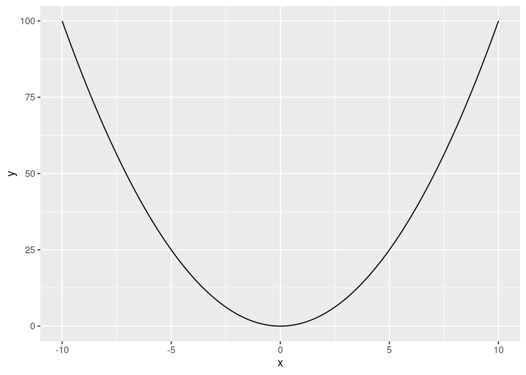

```r
# install.packages("ggplot2")
library(ggplot2)
x<-seq(-10,10,0.1)
y=x^2
qplot(x,y,geom='line')
```

You can export plots to incorporate into the  
assignment you turn in. You may have to experiment with how to do this with the software you are using. We will try to help you with this, but you can always save the plot to your desktop and then print it as a separate page and attach it to your solutions.

If you are using MS WORD, there are at least two ways can do this:

[1] You can export this plot for pasting into a WORD document as a PDF. In the lower right pane of RStudio click “Export” then select “Save Plot as PDF”. Select the appropriate PDF size for the plot. Select a good size (4.00 x 6.00 may be a good place to start). Check your plot in “Preview”. When you think that you have a good plot, select a file name and a directory in which to save it. In WORD, select the Insert tab. In the Text group, click Object. In the Object dialog box, click Create fron File. Find the file using Browse, then click Ok.

[2] You can also save the plot as a metafile. To do this, select “Export”, then “copy to Clipboard”, then select “Copy as Metafile”. Make the plot have a height of about 600, but you should experiment with this setting to get a good quality graph that clearly displays the relationships in the plot.

You have learned to use R to do a good deal of work. R will be our “work horse”. We use just enough of R’s capabilities to do the tedious work we need do to implement the procedures we will learn.

Since the class is only an introduction to probability and statistics, We will not learn R in depth.

The class assignments will guide you through what R you will need. But as you go through the please take the time to notice just how much R can do, and how much you will have learned to use R to do. You may even come to think that R is pretty useful and worth learning more about.

The BC&P text is “user friendly” and will be a good beginning reference for the class. Please actively read it. By actively reading, I mean reading the text with RStudio open on your computer and doing the examples as you read the text. That active reading is what we will do in the next R tutorial.

Learning R and the power it can give you to do analysis in depth will be left to other courses given on the UW campus or online. However, while you are in 381 please feel free to learn as much as you wish about using R. Our TAs and I will be happy to help you.

Now, take the time to reflect on just how far you have progressed in starting to use R. No matter whatever tedious work We use R to do for us, that is all R can do for us. It can not ever substitute for our thinking! It will be your ability to think that will make you valuable in your careers.

It always will be up to us to figure out what data we need, how to gather it, what exploration of it we should do, what assumptions are appropriate, what analyses are appropriate, and finally what does the analysis mean in the context of our problem.

R, like all other software, was programmed by people to perform certain specified tasks. It does not know if what you are asking it to do is legitimate, if it meets the underlying assumptions that validate what you are using it to do. It will gladly violate any and all assumptions as this violation does not contradict what it is programmed to do. It will treat integers as real numbers. It will work with invalid data. That, is where you come.  
You must know that what you are doing is correct. You must know what you expect to come out of the software, and that what you see makes sense.

In class we will spend time learning the tedious tasks of the calculations that R is doing for us. This is absolutely necessary. That will help you become a knowledgable user and interpreter of data and the results of its analysis because you will know what is actually being done with the data. But, once we have learned how to do the work, we will make R do most of the tedious  
work of the analysis for us; saving most of our for time interpreting the results of that analysis and drawing conclusions from it.

Never forget that the results of our efforts are ultimately going to be used by human beings to make decisions. we must do good work so those decisions may be meaningful and well made.

These ideas will be emphasized throughout the rest of the course.

Please reread pages iv - 8 (up to section 1.5). Then please read section 1.5 thru page 34. some of this new reading will now be review.  
That repetition will be beneficial. It also serves to let you know that you have already learned a good deal about using R.

You will notice that when we downloaded and opened RStudio, all four panes appeared, so when you are asked to use the Console, just use it. There is no need to close the Script pane only to reopen it.

Make sure to accompany your reading with using R to reproduce what you are reading. That is active reading. (Please note that Figure 1.8,on page 20, was done using a Mac, not a PC.)

Use the area below for your scripts as you work you way through section 1.5 thru page 34. Add more lines as you need them.

Save your work to your desktop or some other file. DO NOT FORGET TO DO THIS! You have done a lot of work. Do not lose it.

```
        CONGRATULATIONS!!!
```

Now that you have completed this tutorial. Please go on to “Second R Tutorial”